# Modeling shootings and the ceasefire effect using bayesian structural / state space time series model

peter phalen

4/21/2019

In [this markdown](https://www.peterphalen.com/ceasefire/) I had modeled shootings in Baltimore (from 2012-present) using a Bayesian generalized additive model. This has a lot of benefits mostly in terms of the ease of interpreting the model components and the ease of writing up the model (e.g., fitting a cubic spline is apparently equivalent to fitting a univariate local linear trend model using a Kalman filter). However, the approach is slightly non-standard in the time series literature. So, I wanted to redo everything with a state-space model, coded up in Stan, to show the similarity of the results.

First we process all the data.

```r
library(tidyverse)
library(rstan)
library(lubridate)
require(ggfortify)
library(scales)
library(bayesplot)

# data came from here: https/:/data.baltimorecity.gov/Public-Safety/BPD-Part-1-Victim-Based-Crime-Data/wsfq-mvij/data
# but I'm loading a copy that I backed up on github
bpd <- read_csv("https://raw.githubusercontent.com/peterphalen/ceasefire/master/BPD_Part_1_Victim_Based_Crime_Data.csv")

# subset to shootings or homicides with a firearm
bpd <- subset(bpd, Description == "SHOOTING" |
                (Description == "HOMICIDE" & Weapon == "FIREARM"))

bpd$CrimeDate <- as.Date(bpd$CrimeDate, format = "%m/%d/%Y")

# there are many crimes per day. collapse to daily counts
daily <- bpd %>% group_by(CrimeDate) %>% summarise(shootings = n())

# fill missing dates, because some had no shootings
full.ts <- data.frame(CrimeDate = seq(daily$CrimeDate[1],
                                      daily$CrimeDate[nrow(daily)], by="day"))
daily <- full_join(full.ts,daily)
daily <- daily %>% group_by(CrimeDate) %>% mutate_all(funs(ifelse(is.na(.),0,.)))
```

The time series looks like this:

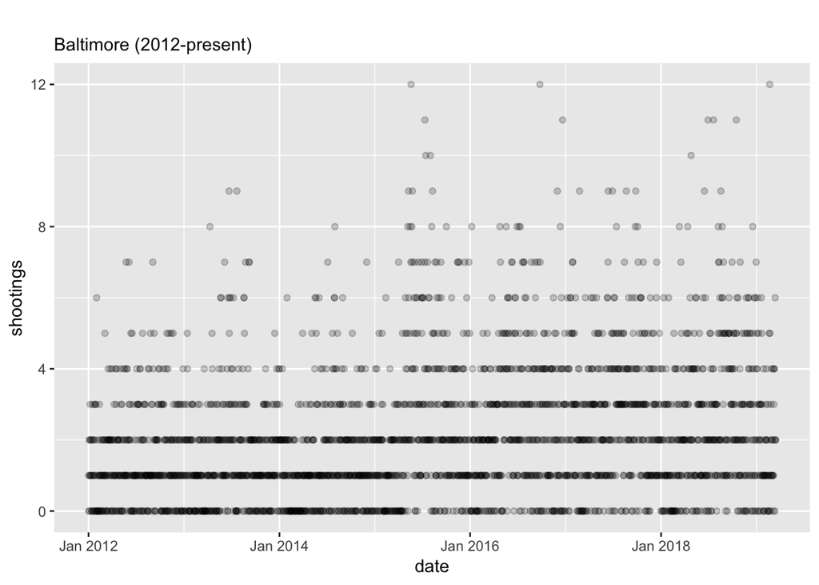

```r
ggplot(daily) +
  aes(x=CrimeDate, y=shootings) +
  geom_point(alpha=.2) +
  xlab("date") +
  ylab("shootings") +
  scale_y_continuous(breaks=c(0,4,8,12)) +
  scale_x_date(labels = date_format("%b %Y")) +
  ggtitle(" ",
          subtitle="Baltimore (2012-present)")
```

We define a dummy code for ceasefire.

```r
ceasefire.initial <-
  as.Date(
    c("08/04/2017",
      "11/03/2017",
      "02/02/2018",
      "05/11/2018",
      "08/03/2018",
      "11/02/2018",
      "02/01/2019",
      "05/10/2019"),
    format="%m/%d/%Y")

ceasefire.weekends <-
  lapply(ceasefire.initial,
         function(x){
           seq(from=x,
               by="day",
               length.out=3)})

ceasefire.weekends <- do.call("c",
                              ceasefire.weekends)

# dummy variable
daily$ceasefire <- ifelse(daily$CrimeDate %in% ceasefire.weekends, 1, 0)
```

We code up a bayesian structural time series model. This model was initially constructed with reference to https://github.com/sinhrks/stan-statespace, except that they had seasonality represented with this equation
$$\gamma_t \text{ ~ } \mathcal{N}(\sum_{j=1}^{s-1} \gamma_{t-j},\sigma_{seas})$$
which is unacceptably slow due to the size of the yearly season when the data is daily, so reformulated [with help from the stan community](https://discourse.mc-stan.org/t/structural-time-series-with-seasonality-sampling-very-slowly/8552/13).

```r
model_code <- "data {
  int<lower=1> n;   // n = 2632
  int y[n]; // number of shootings per day
  vector<lower=0,upper=1>[n] ceasefire;
}
transformed data {
  int<lower=1,upper=365> yday[n];
  int<lower=1,upper=7> wday[n];
  for (i in 1:n) yday[i] = i % 365 + 1;
  for (i in 1:n) wday[i] = i % 7 + 1;
}
parameters {
  real baseline;
  vector[n] mu_innovations;
  vector[365] y_seasonal_innovations; // yearly seasonality
  vector[7] w_seasonal_innovations; // weekly seasonality

  real<lower=0> sigma_mu;
  real<lower=0> sigma_yday;
  real<lower=0> sigma_wday;

  real ceasefire_effect;
}
transformed parameters {
  // zero-mean seasonal terms
  vector[365] y_seasonal;
  vector[7] w_seasonal;

  vector[n] mu;
  { vector[365] y_seasonal_with_trend;
    real y_trend;
    y_seasonal_with_trend = cumulative_sum(y_seasonal_innovations);
    y_trend = y_seasonal_with_trend[365];
    for (i in 1:365)
        y_seasonal[i] = sigma_yday/100 * (y_seasonal_with_trend[i] - y_trend * i/365.0);
  }

  { vector[7] w_seasonal_with_trend;
    real w_trend;
    w_seasonal_with_trend = cumulative_sum(w_seasonal_innovations);
    w_trend = w_seasonal_with_trend[7];
    for (i in 1:7)
        w_seasonal[i] = sigma_wday/100 * (w_seasonal_with_trend[i] - w_trend * i/7.0);
  }

  mu = sigma_mu/100 * cumulative_sum(mu_innovations);
}
model {
  y_seasonal_innovations ~ normal(0, 1);
  w_seasonal_innovations ~ normal(0, 1);
  mu_innovations ~ normal(0, 1);

  y ~ poisson_log(baseline + mu + y_seasonal[yday] + w_seasonal[wday] + ceasefire_effect * ceasefire);
  sigma_mu ~ lognormal(-3.5 + log(100), 2);
  sigma_yday ~ lognormal(-3.5 + log(100), 2);
} "
```

Stan takes data as a list.

```r
stan_data <- list(y <- daily$shootings,
                  n <- nrow(daily),
                  ceasefire <- daily$ceasefire)
```

Fit the model (this takes a long time):

```r
fit <- stan(model_code=model_code, data=stan_data, cores=3, chains=3, iter = 500, control=list(adapt_delta=.95, max_treedepth=15))
```

Here’s the yearly seasonal component estimated by the model (on the untransformed scale).

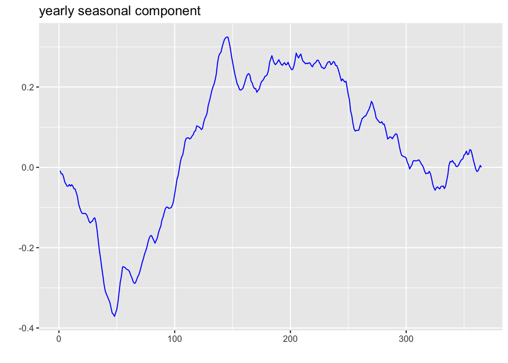

```r
seasonal <- get_posterior_mean(fit, pars="y_seasonal")[, 'mean-all chains']
seasonal <- ts(seasonal)
autoplot(seasonal, ts.colour = 'blue') + ggtitle("yearly seasonal component")
```

And a weekly seasonal component.

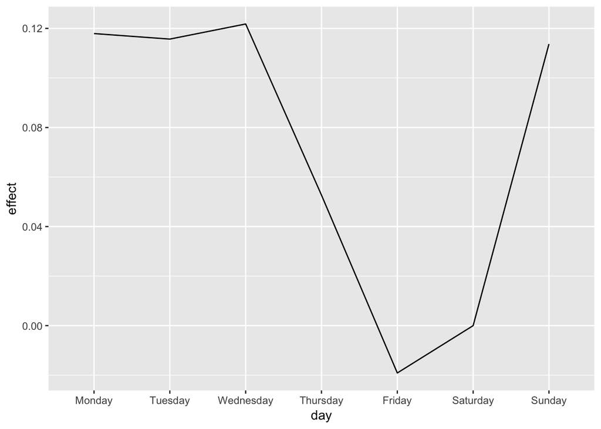

```r
seasonal <- get_posterior_mean(fit, pars="w_seasonal")[, 'mean-all chains']

# associate index with weekday names
daily$weekday <- weekdays(daily$CrimeDate)
daily$weekday <- factor(daily$weekday,
levels=c("Monday","Tuesday","Wednesday","Thursday","Friday","Saturday","Sunday"))
week_names <- head(daily$weekday,7)
seasonal <- data.frame(day = week_names, effect=seasonal)

ggplot(seasonal) + aes(x = day, y = effect, group=1) + geom_line()
```

And here’s the local linear trend plotted over the data (trend in blue, observed time series in grey):

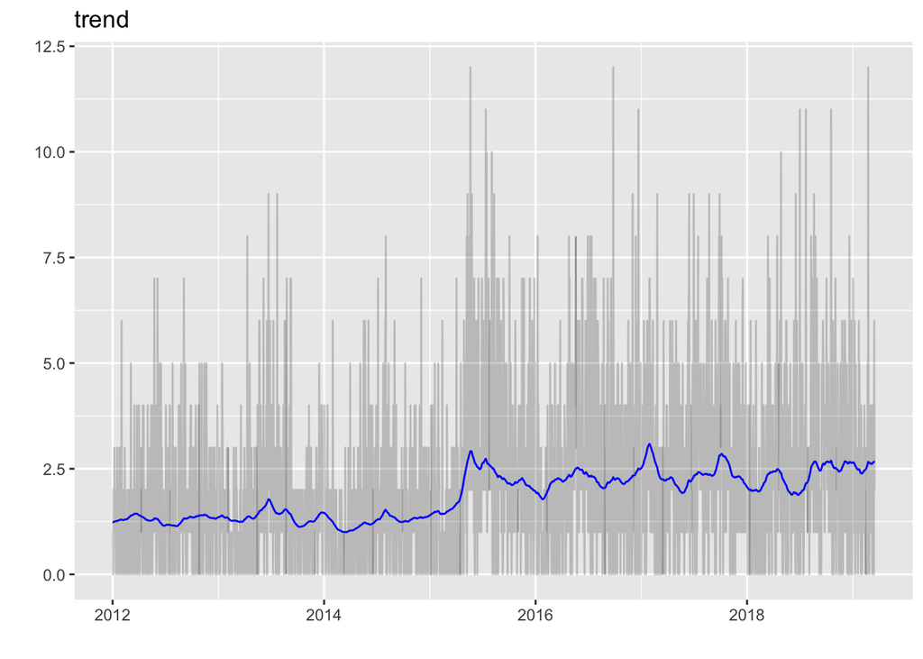

```r
mu <- get_posterior_mean(fit, pars="mu")[, 'mean-all chains']
baseline <- get_posterior_mean(fit, pars="baseline")[, 'mean-all chains']
yhat <- baseline + mu
yhat <- exp(yhat)

y <- ts(daily$shootings, start = c(2012, 1), frequency = 365)

p <- autoplot(y, alpha=.2)
yhat <- ts(yhat, start = start(y), frequency = frequency(y))
p <- autoplot(yhat, p = p, ts.colour="blue")
p + ggtitle("trend")
```

And here is the estimated effect of Ceasefire, plotted directly as an odds ratio:

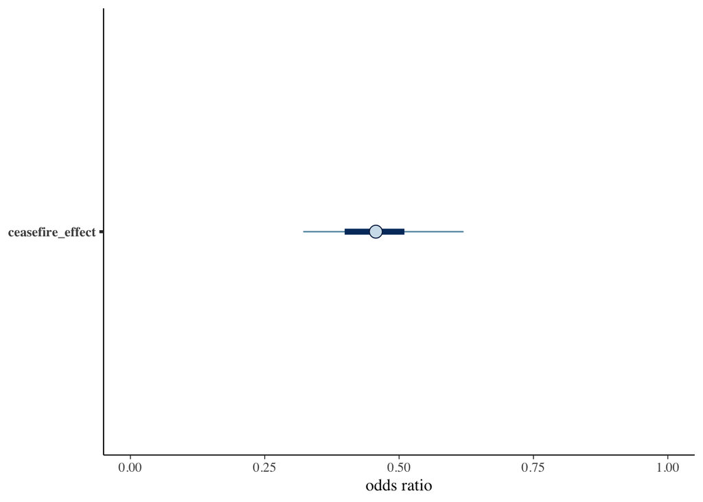

```r
ceasefire.effect <- as.array(fit, pars = "ceasefire_effect")
# scale to an odds ratio by exponentiating
ceasefire.effect <- exp(ceasefire.effect)
mcmc_intervals(ceasefire.effect) +
  xlab("odds ratio") +
  xlim(c(0,1))
```

Despite the very different model specification, this finding matches the [GAM model](https://www.peterphalen.com/ceasefire/) almost perfectly.